# COMP 4299 Assignment 5

Briana McSpadden

2023-04-05

## Section 1: Introduction of Data

The data in this report looks into different words, characters, and capital letter run lengths present in different emails. The goal is to predict whether or not the email is considered “spam.” As we all know, spam emails can be annoying and cause clutter in email accounts that may cause individuals to miss important information. Being able to use predictor words to classify spam emails can help to de-clutter email accounts. In this data set, there are 57 predictors, 1 outcome variable, and 4,600 observations.

##### The Data

As mentioned above, the predictor variables in this data set can be classified in three areas- word frequency, character frequency, and capital letter run length.

- **Word Frequency**: The word frequency predictor variables are numeric, continuous variables. There are forty-eight total word frequency predictors in the data set. They are calculated by multiplying one hundred times the number of times that word appears in the email, divided by the total number of words in the email. An example of a word frequency predictor in the data set is “freq_make”. In the context of the equation, this predictor measure the number of times that the word “make” appears in the data, multiplies it by one hundred, and then divides by the total number of words in the email.
- **Character Frequency**: The character frequency predictor variables are numeric, continuous variables. There are six total character frequency predictors in the data set. They are calculated by multiplying one hundred times the total number of times that character appears in the data set, divided by the total number of characters in the email. An example of a character frequency predictor in the data set is “exclam”. This is for exclamation marks.
- **Capital Run Length**: The capital-run-length predictor variables are numeric, continuious variables. They look into the average, longest, and total amount of uninterrupted sequences of capital letters. There are three of these predictor variables- average, longest, and total.
- **SpamORnot**: This is the outcome variable. It is a factor with levels 0 and 1. A value of 1 indicates that the email is spam and a 0 indicates not spam.

##### First 6 Rows of the Data for Each Type of Predictor

| freq_make | parenth | cap_avg | spamORnot |
| --- | --- | --- | --- |
| 0.21 | 0.132 | 5.114 | 1 |
| 0.06 | 0.143 | 9.821 | 1 |
| 0.00 | 0.137 | 3.537 | 1 |
| 0.00 | 0.135 | 3.537 | 1 |
| 0.00 | 0.223 | 3.000 | 1 |
| 0.00 | 0.054 | 1.671 | 1 |

## Section 2: Preparing the Data and Visualizing to Choose Predictors

##### Splitting the data

We are doing a 80/20 split, with 80% of the data going to the training set and 20% of the data going to the testing set.

#### Histograms of the Best Predictors

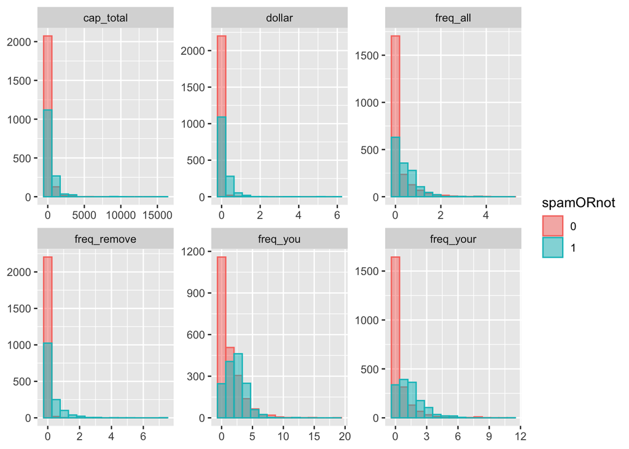

Running a summary of a rpart() function on all of the predictors will assign values of variable importance variables. By running a summary and looking at the histograms, the two predictors that will be used in the two predictor model are **dollar** and **freq_remove.** It’s important to note that the scales for each histogram vary.

##### Boxplots of the 2 chosen predictors:

A further look into the two predictors is shown below with box plots. A logarithmic scale for the dollar predictor box plot was added.

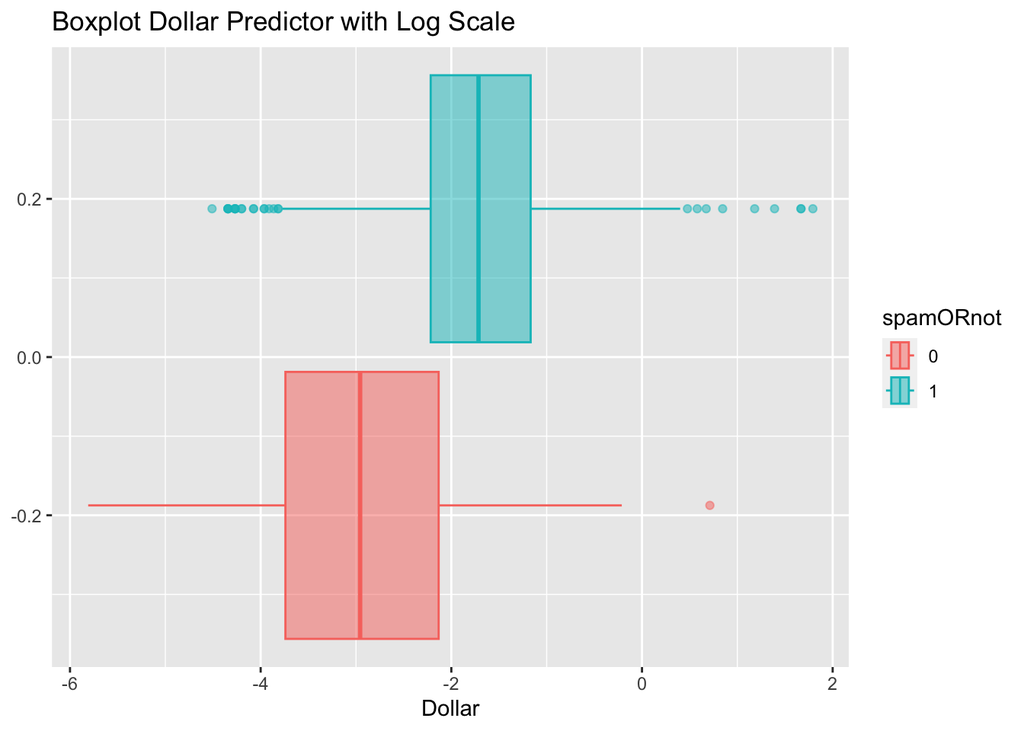

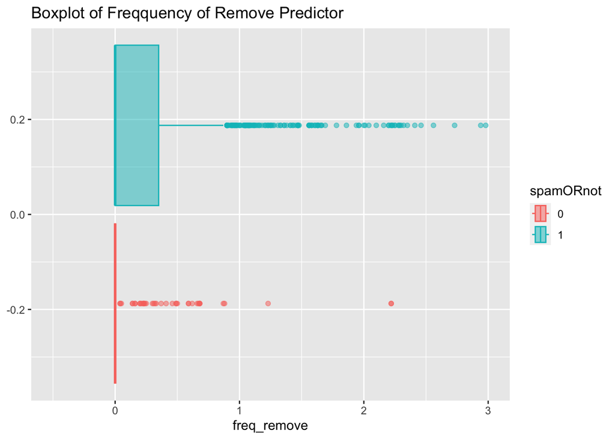

## Section 3: Two Predictor Model

For this section, the two predictors **dollar** and **freq_remove** will be used to create a model. The metrics of the model after being tested with the testing data are shown below:

```
##        Metric Value
## 1    Accuracy 0.850
## 2 Sensitivity 0.703
## 3 Specificity 0.945
```

- **Accuracy:** The model is 85% accurate, meaning it predicted true positive results 85% of the time.
- **Sensitivity:** The model’s sensitivity is 70.3%, meaning 70.3% the time the model will predict spam given that the actual value is spam.
- **Specificity:** The model’s specificity is 94.5%, the best of the three metrics. This means that 94.5% of the time the model will predict not spam given that the actual value is not spam.

#### Visualizing the Data

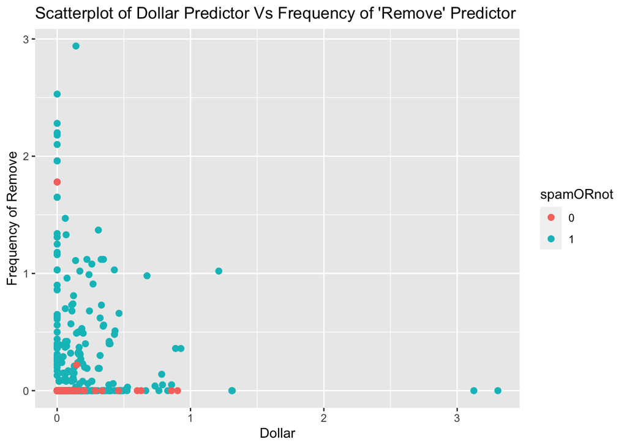

## Section 4: Classification Tree Using RPART

[figure not shown]

[output not shown]

[output cut: 488 more lines]

[output not shown]

```
##        Metric Value
## 1    Accuracy 0.918
## 2 Sensitivity 0.889
## 3 Specificity 0.938
```

- **Accuracy:** The model is 91.8% accurate, meaning it predicted true positive results 91.8% of the time. This is much better than the two predictor model from part three.
- **Sensitivity:** The model’s sensitivity is 88.9%, meaning 88.9% the time the model will predict spam given that the actual value is spam.
- **Specificity:** The model’s specificity is 93.8%, the best of the three metrics. This means that 93.8% of the time the model will predict not spam given that the actual value is not spam.

## Section 5: Conclusion

To ensure that the model’s metrics are reproducible, we will try changing the seed.

```
##        Metric Value
## 1    Accuracy 0.909
## 2 Sensitivity 0.873
## 3 Specificity 0.931
```

Changing the seed results in similar metrics, so we can conclude that the decision tree is reliable. The metrics are slightly lower, but small variations in the metrics is to be expected. Changing the seed helps to see if there are any large drops in accuracy, specificity, or sensitivity. In this case, there are not. Being able to reproduce the results is important to ensure that the model’s accuracy is not specific to the seed it was first set on. It was interesting, while creating the model, to see how the model’s metrics changed based on a slight change in the complexity parameter or in the minimum bucket parameter.